# **Facial Emotion Detection**

## **Problem Definition**

- David Antonio Ortega Alfaro

**The context:** Why is this problem important to solve?

From the problem statement we can see that facial recognition is important in order to correctly asess emotions conveyed by people, because as much as 55% of emotion is conveyed through facial expressions. The task of identifying said emotions is taxing and expenssive for analysts to manually categorize every photo. For this, we can use only some manual categorization and afterwards deploy a Neural Network which can easily categorize this emotions once trained.

This helps free up time for analysts to do other tasks and modernizes the enterprise's usage of technology, adding needed intelligence and categorization for whatever it's purpose may be.

**The objectives:** What is the intended goal?

From the Problem Statement: "to use Deep Learning and Artificial Intelligence techniques to create a computer vision model that can accurately detect facial emotions."

**The key questions:** What are the key questions that need to be answered?

- Which is the model that best performs when categorizing this images?
- What are the parameters which help this identification?
- How can we apply this model to other aplications?

**The problem formulation:** What are we trying to solve using data science?

Solve a categorization problem of images using Deep Learning, specificallly computer vision neural networks, in this case, for classifying human emotions.

## **About the dataset**

The data set consists of 3 folders, i.e., 'test', 'train', and 'validation'. Each of these folders has four subfolders:

**‘happy’**: Images of people who have happy facial expressions.  
**‘sad’**: Images of people with sad or upset facial expressions.  
**‘surprise’**: Images of people who have shocked or surprised facial expressions.  
**‘neutral’**: Images of people showing no prominent emotion in their facial expression at all.

## **Mounting the Drive**

**NOTE:** Please use Google Colab from your browser for this notebook. **Google.colab is NOT a library that can be downloaded locally on your device.**

```python
from google.colab import drive
drive.mount('/content/drive/')
```

## **Importing the Libraries**

```python
import os
import numpy as np
import zipfile
import pandas as pd
import matplotlib.pyplot as plt
import seaborn as sns
from sklearn.model_selection import train_test_split
from sklearn.metrics import classification_report
from sklearn.metrics import confusion_matrix
import tensorflow as tf
from tensorflow.keras.models import Sequential
from tensorflow.keras.layers import Dense, Dropout, Activation, BatchNormalization
from tensorflow.keras.losses import categorical_crossentropy
from tensorflow.keras.optimizers import Adam
from tensorflow.keras.utils import to_categorical
from tensorflow.keras import backend
from tensorflow.keras.preprocessing.image import load_img, img_to_array
from tensorflow.keras.preprocessing.image import ImageDataGenerator
import random
```

### **Let us load and unzip the data**

**Note:**

- You must download the dataset from the link provided on Olympus and upload the same on your Google drive before executing the code in the next cell.
- In case of any error, please make sure that the path of the file is correct as the path may be different for you.

```python
path = '/content/drive/MyDrive/MIT/capstone_project/Facial_emotion_images.zip'

# Files are extracted in /content/Facial_emotion_images
with zipfile.ZipFile(path, 'r') as zip_ref:
    zip_ref.extractall()
```

```python
os.listdir('/content/Facial_emotion_images')
```

```
['train', 'validation', 'test']
```

```python
os.listdir('/content/Facial_emotion_images/test/')
```

```
['neutral', 'sad', 'surprise', 'happy']
```

```python
os.listdir('/content/Facial_emotion_images/test/happy/')
```

```
['15810.jpg',
 '15789.jpg',
 '15733.jpg',
 '15782.jpg',
 '15801.jpg',
 '15851.jpg',
 '15838.jpg',
 '15786.jpg',
 '15822.jpg',
 '15812.jpg',
 '15711.jpg',
 '15744.jpg',
 '15817.jpg',
 '15803.jpg',
 '15765.jpg',
 '15776.jpg',
 '15792.jpg',
 '15853.jpg',
 '15728.jpg',
 '15748.jpg',
 '15818.jpg',
 '15832.jpg',
 '15781.jpg',
 '15710.jpg',
 '15762.jpg',
 '15775.jpg',
 '15787.jpg',
 '15730.jpg',
 '15852.jpg',
 '15705.jpg',
 '15799.jpg',
 '15707.jpg']
```

## **Visualizing our Classes**

Let's look at our classes.

**Write down your observation for each class. What do you think can be a unique feature of each emotion, that separates it from the remaining classes?**

### **Happy**

```python
print(len(os.listdir('/content/Facial_emotion_images/train/happy/')), 'Images in the train folder')
print(len(os.listdir('/content/Facial_emotion_images/test/happy/')), 'Images in the test folder')
print(len(os.listdir('/content/Facial_emotion_images/validation/happy/')), 'Images in the validation folder')
```

```
3976 Images in the train folder
32 Images in the test folder
1825 Images in the validation folder
```

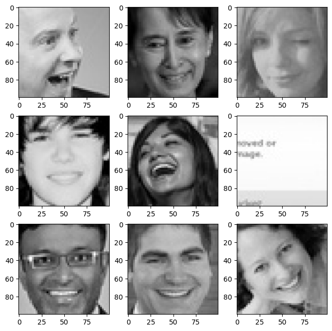

```python
# Plotting some of the images
happy_imgs = os.listdir('/content/Facial_emotion_images/test/happy/')

plt.figure(figsize= (8,8))
for i in range(1, 10, 1):
    plt.subplot(3, 3, i)
    img = load_img('/content/Facial_emotion_images/test/happy/'+happy_imgs[i], target_size = (100, 100))
    plt.imshow(img)

plt.show()
```

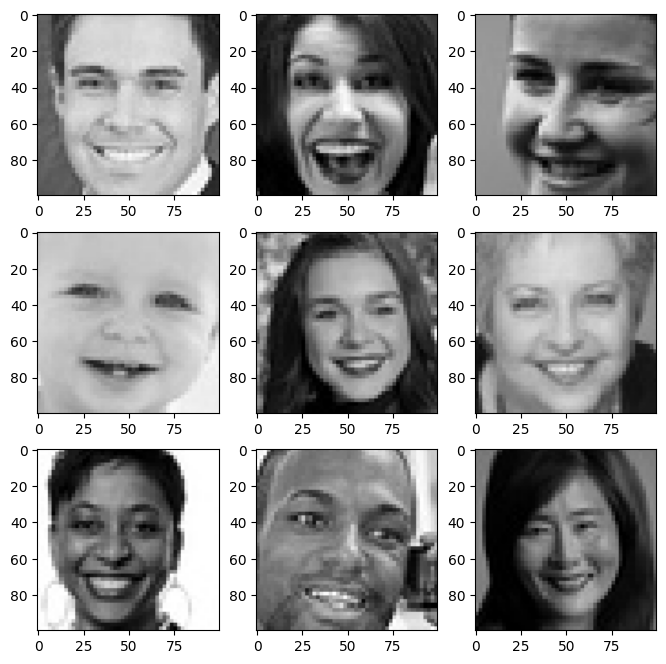

```python
happy_imgs = os.listdir('/content/Facial_emotion_images/train/happy/')

plt.figure(figsize= (8,8))
for i in range(1, 10, 1):
    plt.subplot(3, 3, i)
    img = load_img('/content/Facial_emotion_images/train/happy/'+happy_imgs[i], target_size = (100, 100))
    plt.imshow(img)

plt.show()
```

[figure not shown]

```python
happy_imgs = os.listdir('/content/Facial_emotion_images/validation/happy/')

plt.figure(figsize= (8,8))
for i in range(1, 10, 1):
    plt.subplot(3, 3, i)
    img = load_img('/content/Facial_emotion_images/validation/happy/'+happy_imgs[i], target_size = (100, 100))
    plt.imshow(img)

plt.show()
```

### **Sad**

```python
print(len(os.listdir('/content/Facial_emotion_images/train/sad/')), 'Images in the train folder')
print(len(os.listdir('/content/Facial_emotion_images/test/sad/')), 'Images in the test folder')
print(len(os.listdir('/content/Facial_emotion_images/validation/sad/')), 'Images in the validation folder')
```

```
3982 Images in the train folder
32 Images in the test folder
1139 Images in the validation folder
```

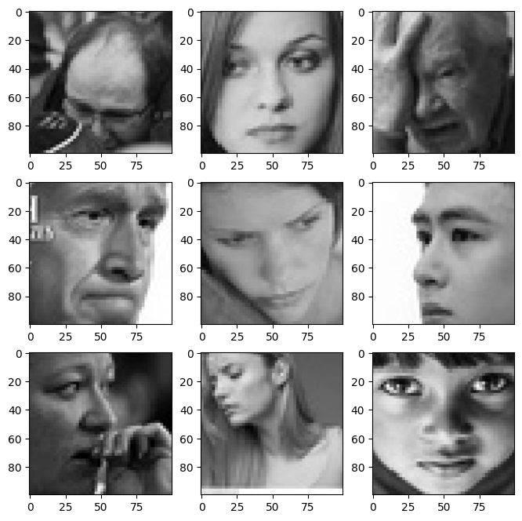

```python
sad_imgs = os.listdir('/content/Facial_emotion_images/test/sad/')

plt.figure(figsize= (8,8))
for i in range(1, 10, 1):
    plt.subplot(3, 3, i)
    img = load_img('/content/Facial_emotion_images/test/sad/'+sad_imgs[i], target_size = (100, 100))
    plt.imshow(img)

plt.show()
```

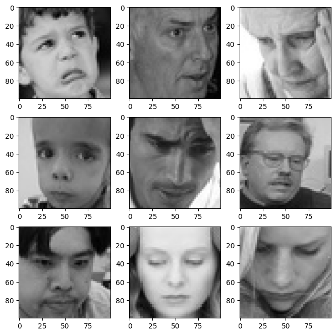

```python
sad_imgs = os.listdir('/content/Facial_emotion_images/train/sad/')

plt.figure(figsize= (8,8))
for i in range(1, 10, 1):
    plt.subplot(3, 3, i)
    img = load_img('/content/Facial_emotion_images/train/sad/'+sad_imgs[i], target_size = (100, 100))
    plt.imshow(img)

plt.show()
```

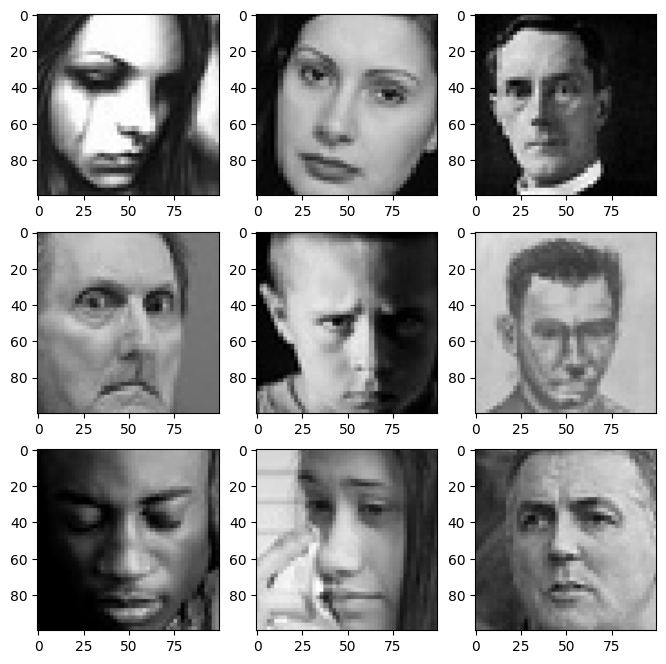

```python
sad_imgs = os.listdir('/content/Facial_emotion_images/validation/sad/')

plt.figure(figsize= (8,8))
for i in range(1, 10, 1):
    plt.subplot(3, 3, i)
    img = load_img('/content/Facial_emotion_images/validation/sad/'+sad_imgs[i], target_size = (100, 100))
    plt.imshow(img)

plt.show()
```

### **Neutral**

```python
print(len(os.listdir('/content/Facial_emotion_images/train/neutral/')), 'Images in the train folder')
print(len(os.listdir('/content/Facial_emotion_images/test/neutral/')), 'Images in the test folder')
print(len(os.listdir('/content/Facial_emotion_images/validation/neutral/')), 'Images in the validation folder')
```

```
3978 Images in the train folder
32 Images in the test folder
1216 Images in the validation folder
```

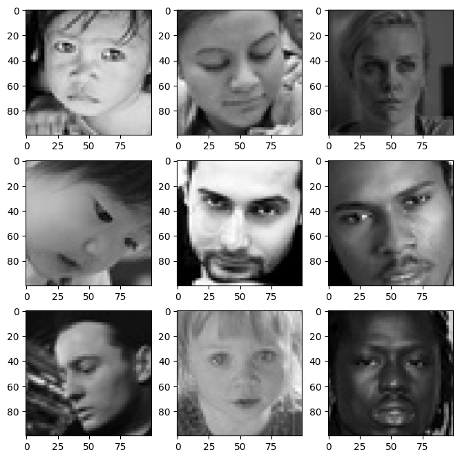

```python
neutral_imgs = os.listdir('/content/Facial_emotion_images/validation/neutral/')

plt.figure(figsize= (8,8))
for i in range(1, 10, 1):
    plt.subplot(3, 3, i)
    img = load_img('/content/Facial_emotion_images/validation/neutral/'+neutral_imgs[i], target_size = (100, 100))
    plt.imshow(img)

plt.show()
```

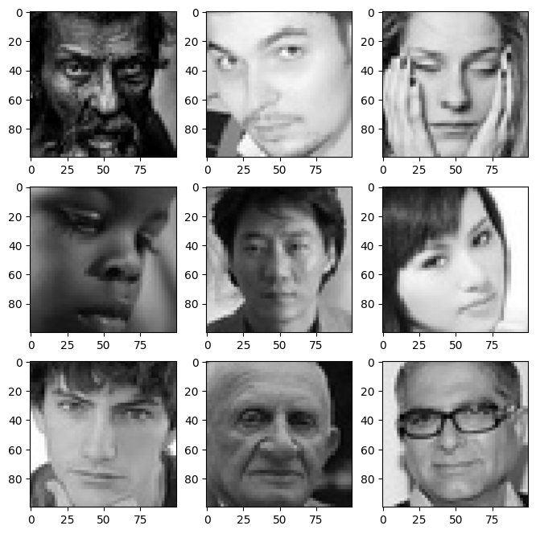

```python
neutral_imgs = os.listdir('/content/Facial_emotion_images/test/neutral/')

plt.figure(figsize= (8,8))
for i in range(1, 10, 1):
    plt.subplot(3, 3, i)
    img = load_img('/content/Facial_emotion_images/test/neutral/'+neutral_imgs[i], target_size = (100, 100))
    plt.imshow(img)

plt.show()
```

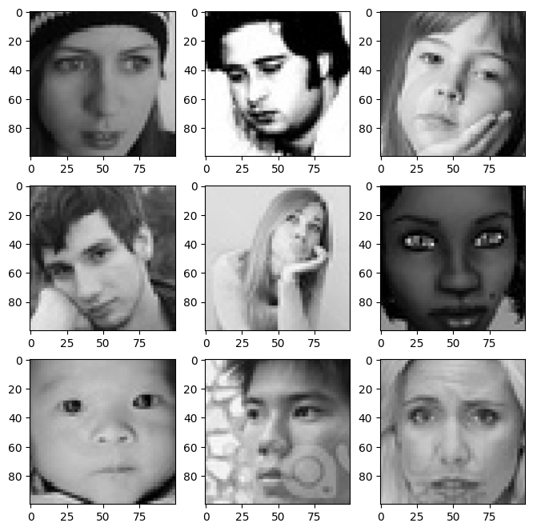

```python
neutral_imgs = os.listdir('/content/Facial_emotion_images/train/neutral/')

plt.figure(figsize= (8,8))
for i in range(1, 10, 1):
    plt.subplot(3, 3, i)
    img = load_img('/content/Facial_emotion_images/train/neutral/'+neutral_imgs[i], target_size = (100, 100))
    plt.imshow(img)

plt.show()
```

**Observations and Insights: This set seems to be one of unclassified images. While expressions are generally neutral, some are simmilar to those of the sad and happy set. Again, the set is less balanced than that of the happy set, which will probably affect the classification.**

### **Surprised**

```python
print(len(os.listdir('/content/Facial_emotion_images/train/surprise/')), 'Images in the train folder')
print(len(os.listdir('/content/Facial_emotion_images/test/surprise/')), 'Images in the test folder')
print(len(os.listdir('/content/Facial_emotion_images/validation/surprise/')), 'Images in the validation folder')
```

```
3173 Images in the train folder
32 Images in the test folder
797 Images in the validation folder
```

[figure not shown]

```python
surprise_imgs = os.listdir('/content/Facial_emotion_images/train/surprise/')

plt.figure(figsize= (8,8))
for i in range(1, 10, 1):
    plt.subplot(3, 3, i)
    img = load_img('/content/Facial_emotion_images/train/surprise/'+surprise_imgs[i], target_size = (100, 100))
    plt.imshow(img)

plt.show()
```

[figure not shown]

```python
surprise_imgs = os.listdir('/content/Facial_emotion_images/test/surprise/')

plt.figure(figsize= (8,8))
for i in range(1, 10, 1):
    plt.subplot(3, 3, i)
    img = load_img('/content/Facial_emotion_images/test/surprise/'+surprise_imgs[i], target_size = (100, 100))
    plt.imshow(img)

plt.show()
```

[figure not shown]

```python
surprise_imgs = os.listdir('/content/Facial_emotion_images/validation/surprise/')

plt.figure(figsize= (8,8))
for i in range(1, 10, 1):
    plt.subplot(3, 3, i)
    img = load_img('/content/Facial_emotion_images/validation/surprise/'+surprise_imgs[i], target_size = (100, 100))
    plt.imshow(img)

plt.show()
```

## **Checking Distribution of Classes**

```python
df_train = pd.DataFrame({
    'expression': ['Surprise', 'Neutral', 'Sad', 'Happy'],
    'count': [len(os.listdir('/content/Facial_emotion_images/train/surprise/')),
        len(os.listdir('/content/Facial_emotion_images/train/neutral/')),
        len(os.listdir('/content/Facial_emotion_images/train/sad/')),
        len(os.listdir('/content/Facial_emotion_images/train/happy/'))]})

df_train
```

|  | expression | count |
| --- | --- | --- |
| 0 | Surprise | 3173 |
| 1 | Neutral | 3978 |
| 2 | Sad | 3982 |
| 3 | Happy | 3976 |

```python
df_test = pd.DataFrame({
    'expression': ['Surprise', 'Neutral', 'Sad', 'Happy'],
    'count': [len(os.listdir('/content/Facial_emotion_images/test/surprise/')),
        len(os.listdir('/content/Facial_emotion_images/test/neutral/')),
        len(os.listdir('/content/Facial_emotion_images/test/sad/')),
        len(os.listdir('/content/Facial_emotion_images/test/happy/'))]})
```

```python
df_validation = pd.DataFrame({
    'expression': ['Surprise', 'Neutral', 'Sad', 'Happy'],
    'count': [len(os.listdir('/content/Facial_emotion_images/validation/surprise/')),
        len(os.listdir('/content/Facial_emotion_images/validation/neutral/')),
        len(os.listdir('/content/Facial_emotion_images/validation/sad/')),
        len(os.listdir('/content/Facial_emotion_images/validation/happy/'))]})
```

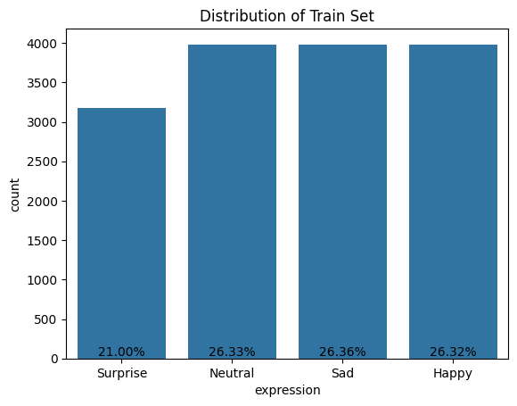

```python
sns.barplot(x = 'expression', y = 'count', data = df_train)
plt.title('Distribution of Train Set')

total = df_train['count'].sum()

for i in range(4):
    percentage = df_train['count'][i] / total
    plt.text(i, percentage, f"{percentage:.2%}", ha='center', va='bottom')
plt.show()
```

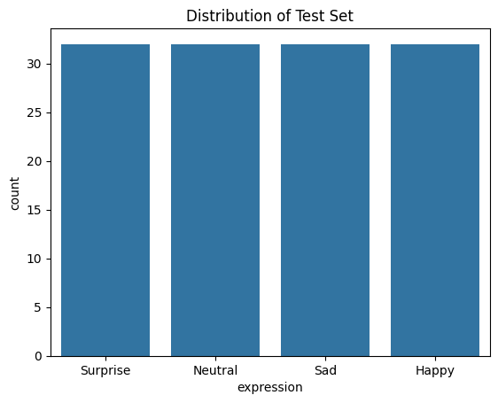

```python
sns.barplot(x = 'expression', y = 'count', data = df_test)
plt.title('Distribution of Test Set')
plt.show()
```

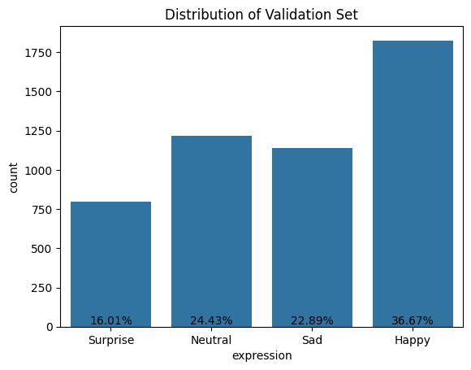

```python
sns.barplot(x = 'expression', y = 'count', data = df_validation)
plt.title('Distribution of Validation Set')
total = df_validation['count'].sum()

for i in range(4):
    percentage = df_validation['count'][i] / total
    plt.text(i, percentage, f"{percentage:.2%}", ha='center', va='bottom')

plt.show()
```

**Observations and Insights: As previously stated, there is a heavy imbalance in the validation set, seeing how most of the images are happy and the surprise are the smallest validation set. This could lean the surprise images to be misscategorized as happy. This idea is further reinfoced seeing how the train set is very balanced but out of the categories the lowest one seems to be the surprise set.**

**Think About It:**

- Are the classes equally distributed? If not, do you think the imbalance is too high? Will it be a problem as we progress?

They are not, as previously stated the surprise category having the lowest amount of observations could lead to a problem.

- Are there any Exploratory Data Analysis tasks that we can do here? Would they provide any meaningful insights?

Maybe, down the line, data augmentation, creating more images out of the ones already in said set, could help, but as of right now i do not think so.

## **Creating our Data Loaders**

In this section, we are creating data loaders that we will use as inputs to our Neural Network.

**You have two options for the color_mode. You can set it to color_mode = 'rgb' or color_mode = 'grayscale'. You will need to try out both and see for yourself which one gives better performance.**

```python
# We create an image data generator to balance and avoid overfitting the model, this will create new variations to existing images
batch_size = 32
img_size = 32 # Small image size due to computation limitations in google collab
folder_path = '/content/Facial_emotion_images/'


datagen_train = ImageDataGenerator(
    rotation_range=10,
    zoom_range=0.1,
    horizontal_flip=True,
    brightness_range=(0.5, 1),
    rescale=1/255
)


train_set = datagen_train.flow_from_directory(
    folder_path + "train",
    target_size=(img_size, img_size),
    color_mode='grayscale',  # or 'rgb'
    batch_size=batch_size,
    class_mode='categorical',
    shuffle=True
)
```

```
Found 15109 images belonging to 4 classes.
```

```python
datagen_test= ImageDataGenerator(
    rotation_range=10,
    zoom_range=0.1,
    horizontal_flip=True,
    brightness_range=(0.5, 1),
    rescale=1/255
)


test_set = datagen_test.flow_from_directory(
    folder_path + "test",
    target_size=(img_size, img_size),
    color_mode='grayscale',  # or 'rgb'
    batch_size=batch_size,
    class_mode='categorical',
    shuffle=True
)
```

```
Found 128 images belonging to 4 classes.
```

```python
datagen_validation = ImageDataGenerator(
    rotation_range=10,
    zoom_range=0.1,
    horizontal_flip=True,
    brightness_range=(0.5, 1),
    rescale=1/255
)


validation_set = datagen_validation.flow_from_directory(
    folder_path + "validation",
    target_size=(img_size, img_size),
    color_mode='grayscale',  # or 'rgb'
    batch_size=batch_size,
    class_mode='categorical',
    shuffle=True
)
```

```
Found 4977 images belonging to 4 classes.
```